## April 10, 2023

## Load packages

```r
setwd("C:/Users/blezn/Desktop/IASTATE/PHD/Federated Learning/Pork Quality")
getwd()
#install.packages("BGData")
#install.packages("BGLR")
#install.packages("coda")
library(coda)
library(BGData)
library(BGLR)
library(tidyverse)
library(data.table)
library(knitr)
knitr::opts_chunk$set(
  echo =TRUE,
  suppressWarnings=TRUE,
  suppressMessages=TRUE)
```

## Genotype Data

```r
geno1 <- fread("genos.csv", header = FALSE, data.table = FALSE)%>% as.matrix()
map <- fread("map.csv", header = TRUE, data.table = FALSE)
subjects <- fread("subjects.csv", header = TRUE, data.table = FALSE)
colnames(geno1) = map$snp
rownames(geno1) = subjects$IID
```

## Commercial Data

- Perform Genomic relationship matrix
- Compute and standardize Z matrix
- Perform the linear predictor
- Set BGLR to fit GBLUP
- Compute $\hat{\beta}$ = ${X}^\prime$${G}^{-1}$$\hat{u}$
- Plot $\hat{u}$ and ${u}$

```r
comm <- fread("pheno_comm.csv", data.table = FALSE)
tmp1 <- which(rownames(geno1)%in%comm$animal)
G <- getG(geno1[unique(tmp1),],nCores=1,verbose=FALSE)
EVD <- eigen(G)
PC <- EVD$vectors[,EVD$values>1e-8]
for(i in 1:ncol(PC)){PC[,i]=PC[,i]*sqrt(EVD$values[i])}
rownames(PC)=rownames(G)

Y <- comm[,c('animal','ph','cg')]
Y <- Y[Y$animal%in%rownames(PC),]
Z <- geno1[unique(tmp1),]
pi <- colMeans(Z)/2
pq <- 2*pi*(1-pi)
Z <- sweep(Z,2,STATS = 2*pi,FUN = '-')
#summary(colMeans(Z))
Z <- Z/sqrt(sum(pq))

common_id <- intersect(as.character(Y$animal),rownames(Z))
G_m <- G[common_id,common_id]
Y_g <- Y[match(as.character(Y$animal),common_id),]
Z_g<-Z[common_id,]
sum(rownames(Z_g)!=as.character(Y_g$animal))
```

```
## [1] 0
```

```r
#summary(colMeans(Z_g))
#summary(sd(Z_g))
G_check<-Z_g%*%t(Z_g)
#summary(diag(G_check))

LP <- list(CG= list(~cg-1, data = Y_g, model = 'BRR'),
           GBLUP=list(K=G_check,model = 'RKHS'))

f_Gc <- BGLR(y=Y_g$ph, ETA = LP, nIter=1500, burnIn= 250, verbose= FALSE)

diag(G_check)=diag(G_check)+1e-5
beta_check<-t(Z_g)%*%chol2inv(chol(G_check))%*%f_Gc$ETA$GBLUP$u
summary(beta_check)
```

```
##        V1
##  Min.   :-0.097625
##  1st Qu.:-0.009626
##  Median :-0.000393
##  Mean   :-0.000221
##  3rd Qu.: 0.009184
##  Max.   : 0.097407
```

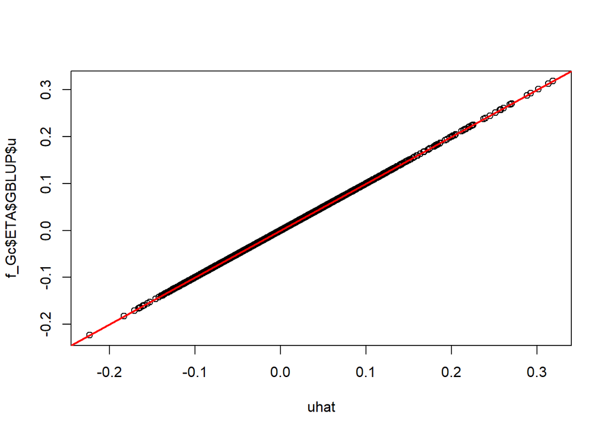

```r
uhat<-Z_g%*%beta_check
plot(uhat,f_Gc$ETA$GBLUP$u)
abline(0, 1, col= "red", lwd= 2)
```

## MSU Data

- Perform Genomic relationship matrix
- Compute and standardize Z matrix
- Set the fixed effects (sex and age)
- Perform the linear predictor
- Set BGLR to fit GBLUP
- Compute $\hat{\beta}$ = ${X}^\prime$${G}^{-1}$$\hat{u}$
- Plot $\hat{u}$ and ${u}$

```r
msu <- fread("pheno_msu.csv", data.table = FALSE)
tmp2 <- which(rownames(geno1)%in%msu$animal)
G1 <- getG(geno1[unique(tmp2),],nCores=1,verbose=FALSE)
EVD_1 <- eigen(G1)
PC_1 <- EVD_1$vectors[,EVD_1$values>1e-8]
for(i in 1:ncol(PC_1)){PC_1[,i]=PC_1[,i]*sqrt(EVD_1$values[i])}
rownames(PC_1) <- rownames(G1)

C <- msu[,c('animal','ph24','cgsl', 'sex', 'age_slg')]
C <- C[C$animal%in%rownames(PC_1),]
Z1<-geno1[unique(tmp2),]

pi_1<-colMeans(Z1)/2
pq_1 <-2*pi_1*(1-pi_1)
Z1<-sweep(Z1,2,STATS = 2*pi_1,FUN = '-')
#summary(colMeans(Z1))
Z1<-Z1/sqrt(sum(pq_1))

common_id1<-intersect(as.character(C$animal),rownames(Z1))
G_ms <- G1[common_id1,common_id1]
C_g<-C[match(as.character(C$animal),common_id1),]
Z_g1<-Z1[common_id1,]
#sum(rownames(Z_g1)!=as.character(C_g$animal))

#summary(colMeans(Z_g1))
#summary(sd(Z_g1))
G_check1<-Z_g1%*%t(Z_g1)
#summary(diag(G_check1))
#sum(is.na(G_check1))

X= model.matrix(~sex+age_slg, data=C_g)
X=X[, -1]

LP1 = list(X= list(X=X, data=C_g, model='FIXED'), MS= list(~cgsl-1, data = C_g, model = 'BRR'),
           GBLUP=list(K=G_check1,model = 'RKHS'))

f_ms = BGLR(y=C_g$ph24, ETA = LP1, nIter=1500, burnIn= 250, verbose= FALSE)

diag(G_check1)=diag(G_check1)+1e-5
beta_check1<-t(Z_g1)%*%chol2inv(chol(G_check1))%*%f_ms$ETA$GBLUP$u
summary(beta_check1)
```

```
##        V1
##  Min.   :-2.097e-02
##  1st Qu.:-2.239e-03
##  Median :-8.475e-06
##  Mean   :-1.198e-05
##  3rd Qu.: 2.268e-03
##  Max.   : 1.987e-02
```

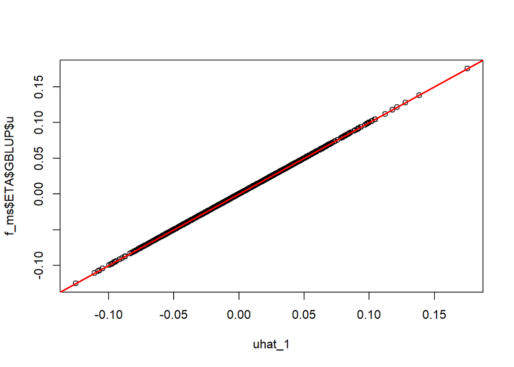

```r
uhat_1<-Z_g1%*%beta_check1
plot(uhat_1,f_ms$ETA$GBLUP$u)
abline(0,1,col='red',lwd=2)
```

## MARC Data

- Perform Genomic relationship matrix
- Compute and standardize Z matrix
- Set the fixed effects (sex and age)
- Perform the linear predictor
- Set BGLR to fit GBLUP
- Compute $\hat{\beta}$ = ${X}^\prime$${G}^{-1}$$\hat{u}$
- Plot $\hat{u}$ and ${u}$

```r
marc <- fread("pheno_marc.csv", data.table = FALSE)
tmp3 <- which(rownames(geno1)%in%marc$animal)
G2 <- getG(geno1[unique(tmp3),],nCores=1,verbose=FALSE)
EVD_2 <- eigen(G2)
PC_2 <- EVD_2$vectors[,EVD_2$values>1e-8]
for(i in 1:ncol(PC_2)){PC_2[,i]=PC_2[,i]*sqrt(EVD_2$values[i])}
rownames(PC_2)=rownames(G2)

Cd <- marc[,c('animal','ph','cg', 'sex', 'age')]
Cd <- Cd[Cd$animal%in%rownames(PC_2),]
Z2<-geno1[unique(tmp3),]

pi_2<-colMeans(Z2)/2
pq_2 <-2*pi_2*(1-pi_2)
Z2<-sweep(Z2,2,STATS = 2*pi_2,FUN = '-')
#summary(colMeans(Z2))
Z2<-Z2/sqrt(sum(pq_2))

common_id2<-intersect(as.character(Cd$animal),rownames(Z2))
G_mc <- G2[common_id2,common_id2]
M_g<-Cd[match(as.character(Cd$animal),common_id2),]
Z_g2<-Z2[common_id2,]
#sum(rownames(Z_g2)!=as.character(M_g$animal))

#summary(colMeans(Z_g2))
#summary(sd(Z_g2))
G_check2<-Z_g2%*%t(Z_g2)
#summary(diag(G_check))
#sum(is.na(G_check2))

R <- model.matrix(~sex+age, data = M_g)
R <- R[, -1]

LP2 <- list(X= list(X=R, data=M_g, model='FIXED'), C= list(~cg-1, data = M_g, model = 'BRR'),
            GBLUP=list(K=G_check2,model = 'RKHS'))

f_mc <- BGLR(y=M_g$ph, ETA = LP2, nIter=1500, burnIn= 250, verbose= FALSE)

diag(G_check2) <- diag(G_check2)+1e-5
beta_check2<-t(Z_g2)%*%chol2inv(chol(G_check2))%*%f_mc$ETA$GBLUP$u
summary(beta_check2)
```

```
##        V1
##  Min.   :-1.587e-02
##  1st Qu.:-2.568e-03
##  Median :-1.010e-04
##  Mean   :-9.496e-05
##  3rd Qu.: 2.361e-03
##  Max.   : 1.499e-02
```

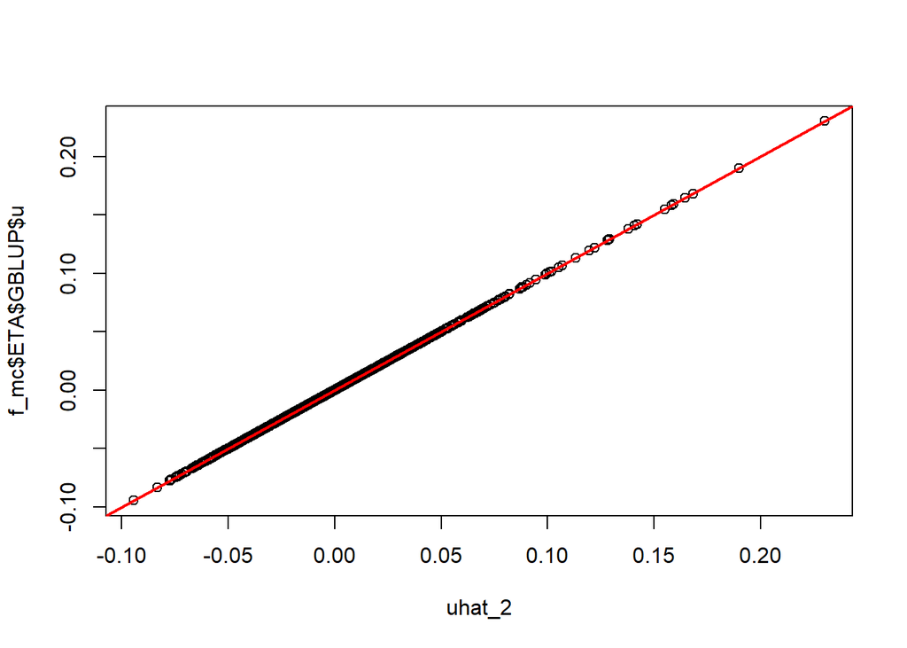

```r
uhat_2<-Z_g2%*%beta_check2
plot(uhat_2,f_mc$ETA$GBLUP$u)
abline(0,1, col = 'red', lwd = 2)
```

## Compute Polygenic Score for MSU

- Load the data (SNP-effects of each dataset)
- Compute the polygenic scores using MSU Z matrix with COMM and MARC SNP_effects
- Compute the correlation between polygenic scores

```r
Data1 <- read.csv("gblub_comm.csv", header=TRUE, row.names = 1, col.names = "comm")
Data2 <- read.csv("gblub_msu.csv", header = TRUE, row.names = 1, col.names = "msu")
Data3 <- read.csv("gblub_marc.csv", header= TRUE, row.names = 1, col.names = "marc")

DATA <- cbind(comm=Data1, msu=Data2, marc=Data3)
head(DATA)
```

```
##                     comm         msu         marc
## MARC0044150 -0.024405074 -0.19435393 -0.006490998
## ASGA0000014 -0.010024583  0.45528573 -0.003155565
## ASGA0000021  0.014015301  0.19564263  0.006490998
## ALGA0000009  0.002821372  0.09472317  0.007425340
## ALGA0000014  0.002822587  0.13255603  0.007425340
## H3GA0000032 -0.008758257 -0.64981360  0.003875778
```

```r
dim(DATA)
```

```
## [1] 37069     3
```

```r
sum(rownames(Data2)!= rownames(Data3))
```

```
## [1] 0
```

```r
## Polygenic score with COMM
K_msu <- geno1[unique(tmp2),]
K_msu<- t(K_msu)
dim(K_msu)
```

```
## [1] 37069   922
```

```r
DT <- data.table(K_msu[,1:922], comm =Data1$comm)
DT_1 <- DT%>%relocate(comm)
DT_n <- as.data.frame(DT_1)
dim(DT_n)
```

```
## [1] 37069   923
```

```r
df2 <- data.frame(DT_n[,])
for (i in 2:ncol(DT_n)) {
  df2[, i] <- DT_n[, i] * DT_n[, 1]
}
df_2<- df2[, -1]

PS1 <- colSums(df_2)%>%as.data.frame()
colnames(PS1) <- c('msu_comm')
head(PS1)
```

```
##           msu_comm
## X991001 -15.842136
## X991002 -12.116565
## X991003 -12.851808
## X991004  -7.196802
## X991006 -17.293744
## X991007  -9.721545
```

```r
## Polygenic score with MARC
DT1 <- data.table(K_msu[,1:922], marc =Data3$marc)
DT_2 <- DT1%>%relocate(marc)
DT_f <- as.data.frame(DT_2)
df3 <- data.frame(DT_f[,])
for (i in 2:ncol(DT_f)) {
  df3[, i] <- DT_f[, i] * DT_f[, 1]
}
df_3 <- df3[, -1]

PS2 <- colSums(df_3)%>%as.data.frame()
colnames(PS2) <- c('msu_marc')
head(PS2)
```

```
##           msu_marc
## X991001 -0.8461762
## X991002 -1.9625510
## X991003 -1.5312766
## X991004  0.1364024
## X991006  0.5840939
## X991007 -0.1638299
```

```r
cor(PS1, PS2)
```

```
##            msu_marc
## msu_comm -0.2967549
```

## Compute BGLR with Polygenic Score for MSU

- Set the fixed effects (sex and age)
- Perform the linear predictor
- Set BGLR to fit GBLUP
- Compute $\hat{\beta}$ = ${X}^\prime$${G}^{-1}$$\hat{u}$
- Plot $\hat{u}$ and ${u}$
- Compute the correlation between $\hat{u}$ and $\hat{u}\_{p}$and $\hat{\beta}$ and $\hat{\beta}\_p$

```r
P <- model.matrix(~sex+age_slg+PS1$msu_comm+PS2$msu_marc, data=C_g)
P <- P[, -1]
head(C_g)
```

```
##   animal ph24 cgsl sex age_slg
## 1 991001 5.54    3   1     182
## 2 991002 5.50    1   2     161
## 3 991003 5.40    1   1     161
## 4 991004 5.33    1   2     161
## 5 991006 5.52    3   2     179
## 6 991007 5.47    1   1     161
```

```r
LP_P = list(P= list(X=P, model='FIXED', data=C_g ), MS= list(~cgsl-1, data = C_g, model = 'BRR'),
            GBLUP=list(K=G_check1,model = 'RKHS'))

f_P = BGLR(y=C_g$ph24, ETA = LP_P, nIter=1500, burnIn= 250, verbose= FALSE)

diag(G_check1)=diag(G_check1)+1e-5
beta_check_P<-t(Z_g1)%*%chol2inv(chol(G_check1))%*%f_P$ETA$GBLUP$u
summary(beta_check_P)
```

```
##        V1
##  Min.   :-2.036e-02
##  1st Qu.:-2.292e-03
##  Median :-2.927e-05
##  Mean   :-1.448e-05
##  3rd Qu.: 2.309e-03
##  Max.   : 1.916e-02
```

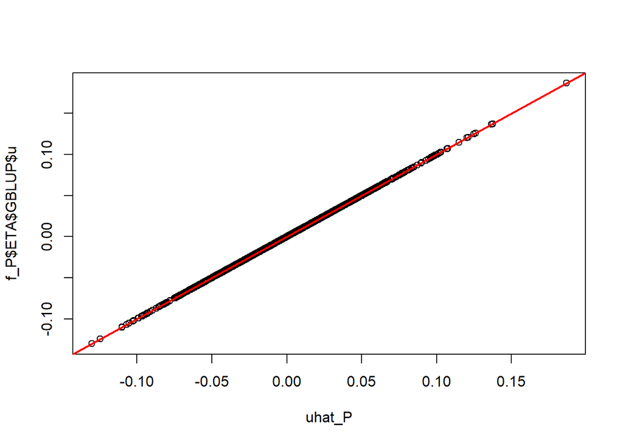

```r
uhat_P<-Z_g1%*%beta_check_P
plot(uhat_P,f_P$ETA$GBLUP$u)
abline(0,1,col='red',lwd=2)
```

```r
cor(uhat_1, uhat_P)
```

```
##           [,1]
## [1,] 0.9786078
```

```r
cor(beta_check1, beta_check_P)
```

```
##          [,1]
## [1,] 0.967157
```

## Compute Polygenic Score for MARC

- Load the data (SNP-effects of each dataset)
- Compute the polygenic scores using MARC Z matrix with COMM and MSU SNP_effects
- Compute the correlation between polygenic scores

```r
poly_marc_msu <- Z2%*%as.matrix(Data2)
poly_marc_comm <- Z2%*%as.matrix(Data1)
poly_marc <- Z2%*%as.matrix(Data3)

cor(poly_marc_msu, poly_marc)
```

```
##            marc
## msu -0.04606051
```

```r
cor(poly_marc_comm, poly_marc)
```

```
##             marc
## comm -0.01762282
```

```r
cor(poly_marc_msu, poly_marc_comm)
```

```
##            comm
## msu -0.02334276
```

```r
#sum(colnames(Z2)!= rownames(Data1))
#sum(colnames(Z2)!= rownames(Data2))
```

## Compute BGLR with Polygenic Score for MARC

- Set the fixed effects (sex and age)
- Perform the linear predictor
- Set BGLR to fit GBLUP
- Compute $\hat{\beta}$ = ${X}^\prime$${G}^{-1}$$\hat{u}$
- Plot $\hat{u}$ and ${u}$
- Compute the correlation between $\hat{u}$ and $\hat{u}\_{p}$ and $\hat{\beta}$ and $\hat{\beta}\_p$

```r
R <- model.matrix(~sex+age+poly_marc_comm+poly_marc_msu, data=M_g)
R <- R[, -1]
dim(poly_marc_comm)
```

```
## [1] 1234    1
```

```r
LP_R = list(R= list(X=R, model='FIXED', data=M_g ), MS= list(~cg-1, data = M_g, model = 'BRR'),
            GBLUP=list(K=G_check2,model = 'RKHS'))

f_R <- BGLR(y=M_g$ph, ETA = LP_R, nIter=1500, burnIn= 250, verbose= FALSE)

diag(G_check2) <- diag(G_check2)+1e-5
beta_check_R<-t(Z_g2)%*%chol2inv(chol(G_check2))%*%f_R$ETA$GBLUP$u
summary(beta_check_R)
```

```
##        V1
##  Min.   :-1.452e-02
##  1st Qu.:-2.094e-03
##  Median :-1.043e-04
##  Mean   :-8.101e-05
##  3rd Qu.: 1.897e-03
##  Max.   : 1.192e-02
```

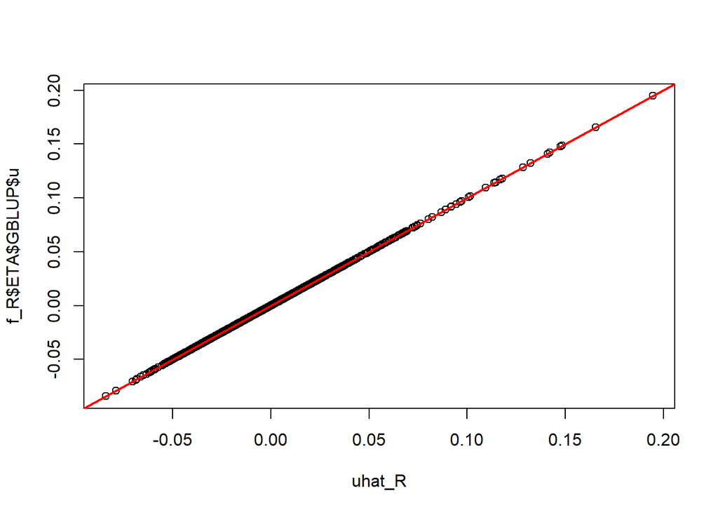

```r
uhat_R<-Z_g2%*%beta_check_R
plot(uhat_R,f_R$ETA$GBLUP$u)
abline(0,1, col = 'red', lwd = 2)
```

```r
cor(uhat_2, uhat_R)
```

```
##          [,1]
## [1,] 0.982687
```

```r
cor(beta_check2, beta_check_R)
```

```
##           [,1]
## [1,] 0.9420397
```

## Compute Polygenic Score for COMM

- Load the data (SNP-effects of each dataset)
- Compute the polygenic scores using COMM Z matrix with MARC and MSU SNP_effects
- Compute the correlation between polygenic scores

```r
poly_comm_msu <- Z%*%as.matrix(Data2)
poly_comm_marc <- Z%*%as.matrix(Data3)
poly_comm <- Z%*%as.matrix(Data1)

cor(poly_comm_msu, poly_comm)
```

```
##           comm
## msu 0.05549968
```

```r
cor(poly_comm_marc, poly_comm)
```

```
##            comm
## marc 0.04691684
```

```r
cor(poly_comm_msu, poly_comm_marc)
```

```
##           marc
## msu 0.03937953
```

```r
#sum(colnames(Z2)!= rownames(Data1))
#sum(colnames(Z2)!= rownames(Data2))
```

- Perform the linear predictor
- Set BGLR to fit GBLUP
- Compute $\hat{\beta}$ = ${X}^\prime$${G}^{-1}$$\hat{u}$
- Plot $\hat{u}$ and ${u}$
- Compute the correlation between $\hat{u}$ and $\hat{u}\_{p}$ and $\hat{\beta}$ and $\hat{\beta}\_p$

```r
R <- model.matrix(~sex+age+poly_marc_comm+poly_marc_msu, data=M_g)
R <- R[, -1]
dim(poly_marc_comm)
```

```
## [1] 1234    1
```

```r
LP_C = list(MC= list(~cg-1, data = Y_g, model = 'BRR'),
            GBLUP=list(K=G_check,model = 'RKHS'))

f_C <- BGLR(y=Y_g$ph, ETA = LP_C, nIter=1500, burnIn= 250, verbose= FALSE)

diag(G_check) <- diag(G_check)+1e-5
beta_check_C<-t(Z_g)%*%chol2inv(chol(G_check))%*%f_C$ETA$GBLUP$u
summary(beta_check_C)
```

```
##        V1
##  Min.   :-0.0922249
##  1st Qu.:-0.0093598
##  Median :-0.0003224
##  Mean   :-0.0002119
##  3rd Qu.: 0.0088711
##  Max.   : 0.0924392
```

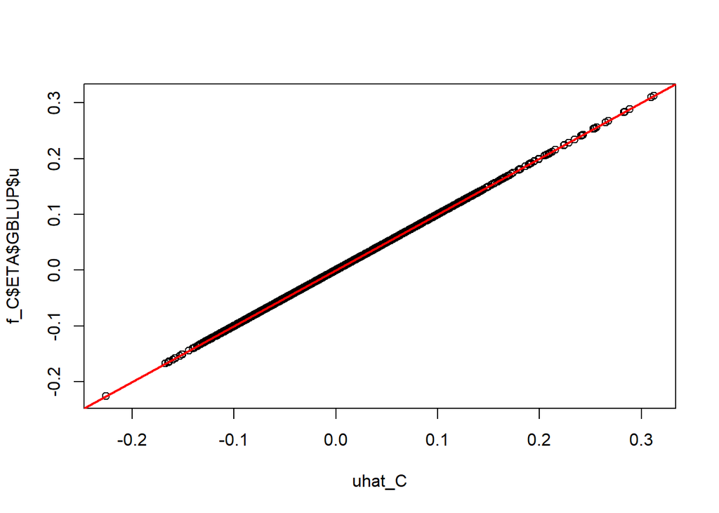

```r
uhat_C<-Z_g%*%beta_check_C
plot(uhat_C,f_C$ETA$GBLUP$u)
abline(0,1, col = 'red', lwd = 2)
```

```r
cor(uhat, uhat_C)
```

```
##           [,1]
## [1,] 0.9959539
```

```r
cor(beta_check, beta_check_C)
```

```
##           [,1]
## [1,] 0.9904279
```